# Fc-OPG PK/PD in healthy post-menopausal women

# Packages

```r
proj <- "models"
library(mrgsolve)
library(dplyr)
library(magrittr)
library(parallel)
library(ggplot2)
```

## Question

- What is the mean change from baseline 14 days after 3 mg/kg SC dose?
- What is the probability that mean CFB is greater than 40%?

# OPG model

```r
mod <- mread("opg", "model")

mod
```

```
.
.
. -------- mrgsolve model object (windows) --------
.   Project: C:/Users/Sam/Doc...b/learn/model
.   source:        opg.cpp
.   shared object: opg-so-714173e15e4
.
.   Time:          start: 0 end: 24 delta: 1
.   >              add: <none>
.   >              tscale: 1
.
.   Compartments:  SC CENT P1 P2 NTX [5]
.   Parameters:    IV TVCL TVVC TVVP1 TVVP2 TVQ1
.   >              TVQ2 TVKA TVVMAX TVKM TVFSC TVKSYN
.   >              TVKDEG TVIC50 [14]
.   Omega:         7x7,3x3
.   Sigma:         2x2,2x2
.
.   Solver:        atol: 1e-08 rtol: 1e-08
.   >              maxsteps: 2000 hmin: 0 hmax: 0
```

Checkout the random effects structure

```r
revar(mod)
```

```
. $omega
. $PK
.          [,1]   [,2]   [,3]   [,4]   [,5]   [,6]  [,7]
. ECL:   0.0391 0.0000 0.0000 0.0000 0.0000 0.0000 0.000
. EVC:   0.0000 0.0102 0.0000 0.0000 0.0000 0.0000 0.000
. EVP1:  0.0000 0.0000 0.0144 0.0000 0.0000 0.0000 0.000
. EVP2:  0.0000 0.0000 0.0000 0.0333 0.0000 0.0000 0.000
. EQ1:   0.0000 0.0000 0.0000 0.0000 0.0379 0.0000 0.000
. EKA:   0.0000 0.0000 0.0000 0.0000 0.0000 0.0457 0.000
. EFSC:  0.0000 0.0000 0.0000 0.0000 0.0000 0.0000 0.263
.
. $PD
.           [,1]   [,2] [,3]
. EKSYN:  0.2810 0.0867 0.00
. EKDEG:  0.0867 0.0325 0.00
. EIC50:  0.0000 0.0000 1.18
.
.
. $sigma
. $PKs
.           [,1]  [,2]
. ADDIV:  0.0193 0.000
. ADDSC:  0.0000 0.733
.
. $PDs
.            [,1] [,2]
. PDPROP:  0.0407  0.0
. PDADD:   0.0000 20.7
```

```r
mod %<>% mrgsolve:::collapse_omega()
mod %<>% mrgsolve:::collapse_sigma()
```

We can render this in to an `Rmarkdown` document

```r
mrgsolve:::render(mod)
```

# Load the simulated posterior

```r
post <- readRDS("data/opgpost.RDS") %>% sample_n(1000)
```

For most of our examples, we are taking output directly from a NONMEM run. This example is a little different: We have changed the column names from `THETA1`, `THETA2` etc … to `TVCL`, `TVVC` etc …

```r
head(post)

## tells you what is missing that is expected
inventory(mod,post)
```

```r
post <- mutate(post, TVVP1 = TVP1, TVVP2 = TVP2)
```

When working with results out of NONMEM, it is common to get the `THETA` , `OMEGA` and `SIGMA` estimates all in a single row in a data frame.

In order to get the information for `OMEGA` and `SIGMA` in to the problem, we need to go into this data and form matrices.

There are two specialized functions to help with this:

- `as_bmat` when the data is in block format
- `as_dmat` when the data is in diagonal format

```r
## put in different matrices for each simulation
omegas <- as_bmat(post,"OMEGA")
sigmas <- as_bmat(post,"SIGMA")
## look at an example of the 1000 matrices
## omegas[[1]]
slice(post, 10)
```

```
. # A tibble: 1 x 80
.    TVCL  TVVC  TVP1  TVP2  TVQ1  TVQ2   TVKA TVVMAX  TVKM  TVFSC TVKSYN
.   <dbl> <dbl> <dbl> <dbl> <dbl> <dbl>  <dbl>  <dbl> <dbl>  <dbl>  <dbl>
. 1   165  2771   439   247  16.4  2.66 0.0138  13480  6.45 0.0719  0.938
. # ... with 69 more variables: TVKDEG <dbl>, TVIC50 <dbl>, OMEGA11 <dbl>,
. #   OMEGA21 <dbl>, OMEGA22 <dbl>, OMEGA31 <dbl>, OMEGA32 <dbl>,
. #   OMEGA33 <dbl>, OMEGA41 <dbl>, OMEGA42 <dbl>, OMEGA43 <dbl>,
. #   OMEGA44 <dbl>, OMEGA51 <dbl>, OMEGA52 <dbl>, OMEGA53 <dbl>,
. #   OMEGA54 <dbl>, OMEGA55 <dbl>, OMEGA61 <dbl>, OMEGA62 <dbl>,
. #   OMEGA63 <dbl>, OMEGA64 <dbl>, OMEGA65 <dbl>, OMEGA66 <dbl>,
. #   OMEGA71 <dbl>, OMEGA72 <dbl>, OMEGA73 <dbl>, OMEGA74 <dbl>,
. #   OMEGA75 <dbl>, OMEGA76 <dbl>, OMEGA77 <dbl>, OMEGA81 <dbl>,
. #   OMEGA82 <dbl>, OMEGA83 <dbl>, OMEGA84 <dbl>, OMEGA85 <dbl>,
. #   OMEGA86 <dbl>, OMEGA87 <dbl>, OMEGA88 <dbl>, OMEGA91 <dbl>,
. #   OMEGA92 <dbl>, OMEGA93 <dbl>, OMEGA94 <dbl>, OMEGA95 <dbl>,
. #   OMEGA96 <dbl>, OMEGA97 <dbl>, OMEGA98 <dbl>, OMEGA99 <dbl>,
. #   OMEGA101 <dbl>, OMEGA102 <dbl>, OMEGA103 <dbl>, OMEGA104 <dbl>,
. #   OMEGA105 <dbl>, OMEGA106 <dbl>, OMEGA107 <dbl>, OMEGA108 <dbl>,
. #   OMEGA109 <dbl>, OMEGA1010 <dbl>, SIGMA11 <dbl>, SIGMA21 <dbl>,
. #   SIGMA22 <dbl>, SIGMA31 <dbl>, SIGMA32 <dbl>, SIGMA33 <dbl>,
. #   SIGMA41 <dbl>, SIGMA42 <dbl>, SIGMA43 <dbl>, SIGMA44 <dbl>,
. #   TVVP1 <dbl>, TVVP2 <dbl>
```

Here is a simple dosing data set to simulate 100 patients with 3 mg/kg Fc-OPG SC x1

```r
sc3 <- expand.ev(ID=1:100, amt=210)
head(sc3)
```

```
.   ID amt evid cmt time
. 1  1 210    1   1    0
. 2  2 210    1   1    0
. 3  3 210    1   1    0
. 4  4 210    1   1    0
. 5  5 210    1   1    0
. 6  6 210    1   1    0
```

We will get the observation design for the simulation through a `tgrid` object

```r
## tgrid creates a time grid for you
# stime(tgrid(0,12,6) + 24)

## end=-1 used to only use addl draw times
des <- tgrid(end=-1,add=c(0,24*14))
des
```

```
. start:  0  end:    -1  delta:  1  offset: 0  min:    0   max:    336
```

When we do replicate simulation, it almost always pays off to construct a function that will carry out one replicate.

Arguments to the function are

- `i` the current simulation replicate
- `data` the dosing data set
- `des` the observation design

```r
sim <- function(i,data,des) {
  ## grabs model file from global environment BAD CODING PRACTICE TO DISREGARD SCOPING
  mod %<>%
    param(slice(post,i)) %>%
    ## update RE matrices
    omat(omegas[[i]]) %>%
    smat(sigmas[[i]])

  mod %>%
    Req(PDDV) %>%
    mrgsim(data=data,tgrid=des,obsonly=TRUE) %>%
    mutate(irep=i) %>%
    mutate(TVIC50=mod$TVIC50, TVQ1=mod$TVQ1, TVVMAX=mod$TVVMAX)
}
```

It is easy to test the function. The 10th replicate will look like this

```r
sim(10,sc3,des)
```

```
. # A tibble: 200 x 7
.       ID  time  PDDV  irep TVIC50  TVQ1 TVVMAX
.    <dbl> <dbl> <dbl> <dbl>  <dbl> <dbl>  <dbl>
.  1  1.00     0  31.9  10.0   3.66  16.4  13480
.  2  1.00   336  37.0  10.0   3.66  16.4  13480
.  3  2.00     0  81.7  10.0   3.66  16.4  13480
.  4  2.00   336  27.3  10.0   3.66  16.4  13480
.  5  3.00     0  63.3  10.0   3.66  16.4  13480
.  6  3.00   336  70.3  10.0   3.66  16.4  13480
.  7  4.00     0  41.8  10.0   3.66  16.4  13480
.  8  4.00   336  19.1  10.0   3.66  16.4  13480
.  9  5.00     0  45.3  10.0   3.66  16.4  13480
. 10  5.00   336  35.3  10.0   3.66  16.4  13480
. # ... with 190 more rows
```

Simulate reps

```r
options(mc.cores=8)
mcRNG()
set.seed(22223)
## can't use multiple cores on Windows :(
# out <- mclapply(1:1000, mc.cores = 8, sim, data=sc3,des=des) %>% bind_rows
out <- lapply(1:1000, sim, data=sc3,des=des) %>% bind_rows

head(out)
```

```
. # A tibble: 6 x 7
.      ID  time   PDDV  irep TVIC50  TVQ1 TVVMAX
.   <dbl> <dbl>  <dbl> <int>  <dbl> <dbl>  <dbl>
. 1  1.00     0 119        1   4.61  15.0  15330
. 2  1.00   336  75.5      1   4.61  15.0  15330
. 3  2.00     0  43.4      1   4.61  15.0  15330
. 4  2.00   336   8.91     1   4.61  15.0  15330
. 5  3.00     0  52.5      1   4.61  15.0  15330
. 6  3.00   336  36.1      1   4.61  15.0  15330
```

Summarise

- First, get the baseline `NTX`
- Then calculate percent CFB

```r
sum <-
  out %>%
  group_by(ID,irep) %>%
  mutate(BASE = first(PDDV), dDV = 100*(PDDV-BASE)/BASE) %>%
  ungroup
```

Filter down to week 2

```r
sum %<>% filter(time==336 & BASE >= 0)
```

Now, get the median

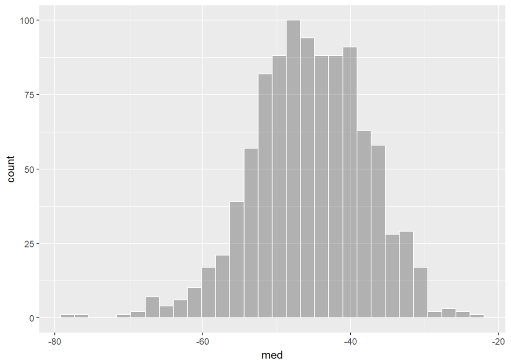

```r
summ <-
  sum %>%
  filter(time==336) %>%
  group_by(irep) %>%
  summarise(med = median(dDV))

ggplot(summ, aes(x=med)) +
  geom_histogram(alpha = 0.4, col="white")
```

## From the abstract

> Subsequent clinical trial simulations demonstrated that a single 3.0-mg/kg SC dose of Fc-OPG would be expected to produce, at 14 days post-dose, a median NTX percentage change from baseline of −45% (with a 95% prediction interval ranging from −34% to −60%)."

```r
ans <- signif(quantile(summ$med, c(0.5,0.025,0.975)),3)

paste0(ans[1], " (", ans[3],",",ans[2],")")
```

```
. [1] "-45.5 (-31.5,-61.1)"
```

Median week-2 change from baseline with 95% interval

Probability that median cfb > 40%

```r
mean(summ$med < -40)
```

```
. [1] 0.762
```

Plot the distribution of the week-2 change from baseline

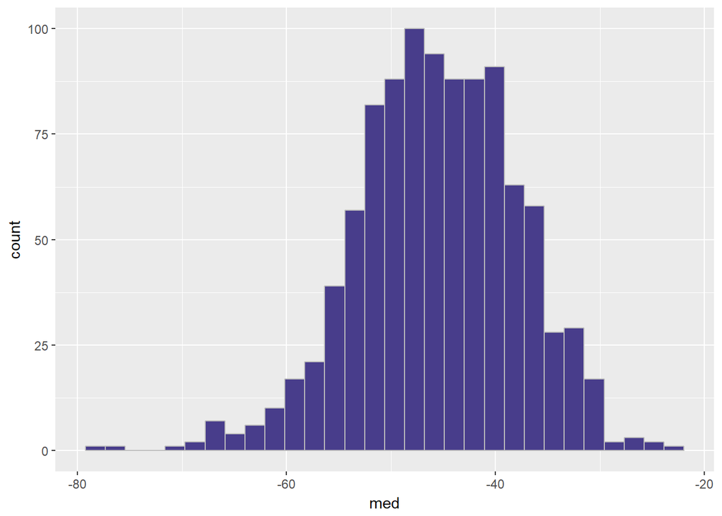

```r
ggplot(summ, aes(x=med)) +
  geom_histogram(fill="darkslateblue", col="grey")
```

# Sensitivity analysis

We are already set up to do the sensitivity analysis

```r
par <- dplyr::distinct(out,irep,TVIC50,TVQ1,TVVMAX)
head(par)
```

```
. # A tibble: 6 x 4
.    irep TVIC50  TVQ1 TVVMAX
.   <int>  <dbl> <dbl>  <dbl>
. 1     1   4.61  15.0  15330
. 2     2   8.50  15.9  14380
. 3     3   5.45  16.2  16910
. 4     4   6.98  15.8  12800
. 5     5   4.80  16.5  11950
. 6     6   3.79  14.7  15950
```

```r
sens <- left_join(summ,par)
head(sens)
```

```
. # A tibble: 6 x 5
.    irep   med TVIC50  TVQ1 TVVMAX
.   <int> <dbl>  <dbl> <dbl>  <dbl>
. 1     1 -47.2   4.61  15.0  15330
. 2     2 -35.5   8.50  15.9  14380
. 3     3 -41.6   5.45  16.2  16910
. 4     4 -39.3   6.98  15.8  12800
. 5     5 -48.5   4.80  16.5  11950
. 6     6 -53.5   3.79  14.7  15950
```

`TVIC50`

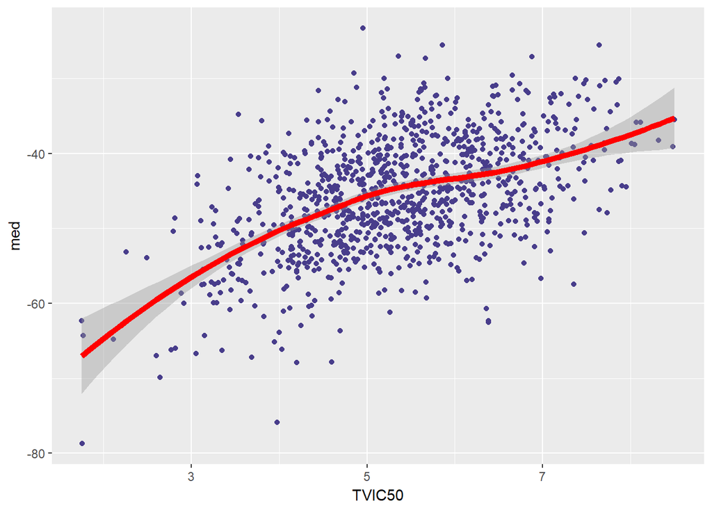

```r
ggplot(sens, aes(TVIC50, med)) +
  geom_point(col="darkslateblue") +
  geom_smooth(method="loess",col="red",lwd=2)
```

`TVVMAX`

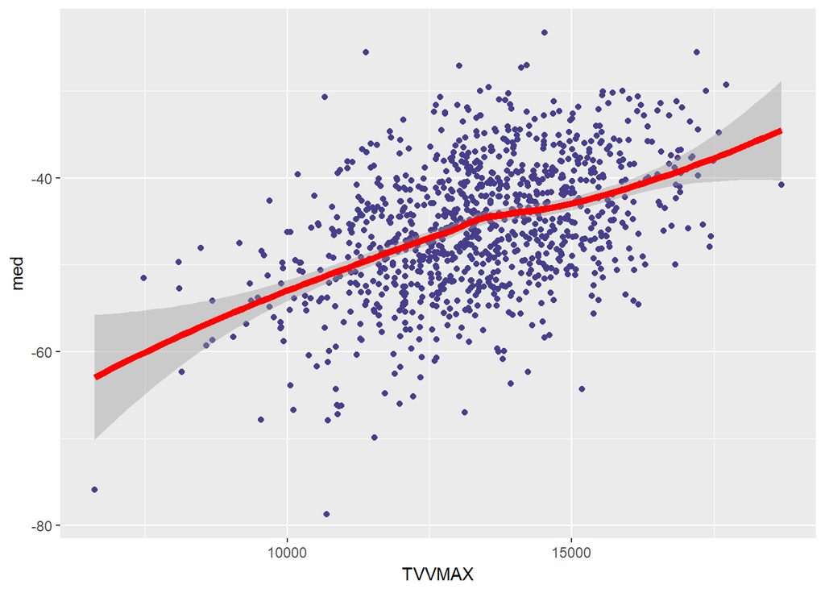

```r
ggplot(sens, aes(TVVMAX, med)) +
  geom_point(col="darkslateblue") +
  geom_smooth(method="loess",col="red",lwd=2)
```

`TVQ`

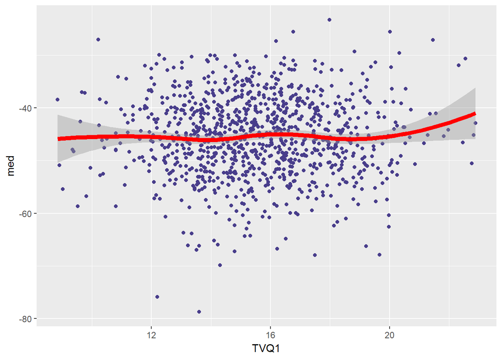

```r
ggplot(sens, aes(TVQ1, med)) +
  geom_point(col="darkslateblue") +
  geom_smooth(method="loess",col="red",lwd=2)
```

## this tells us that precise estimates of Q are not necessary to get an accurate estimate of median change from baseline; however, TVVMAX and TVIC50 will definitely impact the estimate of median change